# ProblemSet1

Xuejing

09/11/2021

# Question 1

Using the rubics in Data Visualization Checklist to grade the below figure:

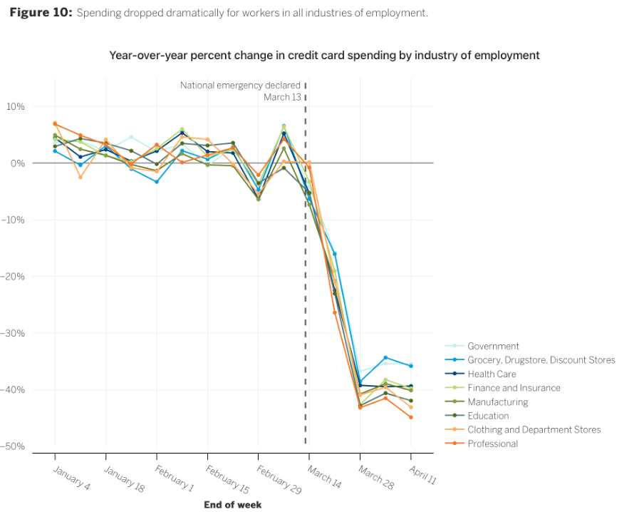

### Arrangement: total score: 8/10

- Proportions are accurate: 2
- Data are intentionally ordered: 0 *(not intentionally ordered or color-coded)*
- Axis intervals are equidistant: 2
- Graph is two-dimensional: 2
- Display is free from decoration: 2

### Color: total score: 2/10

- Color scheme is intentional: 0
- Color is used to highlight key patterns: 0
- Color is legible when printed in black and white: 0
- Color is legible for people with colorblindness: 0
- Text sufficiently contrasts background: 2

### Overall: total score: 8/8

- Graph highlights significant finding or conclusion: 2
- The type of graph is appropriate for data: 2
- Graph has appropriate level of precision: 2
- Individual chart elements work together to reinforce the overarching takeaway message: 2

### Conclusion: total score 34/48 = 71%

# Question 2

One of the worst visualizations that I have created is with the Ask-A-Manager dataset:

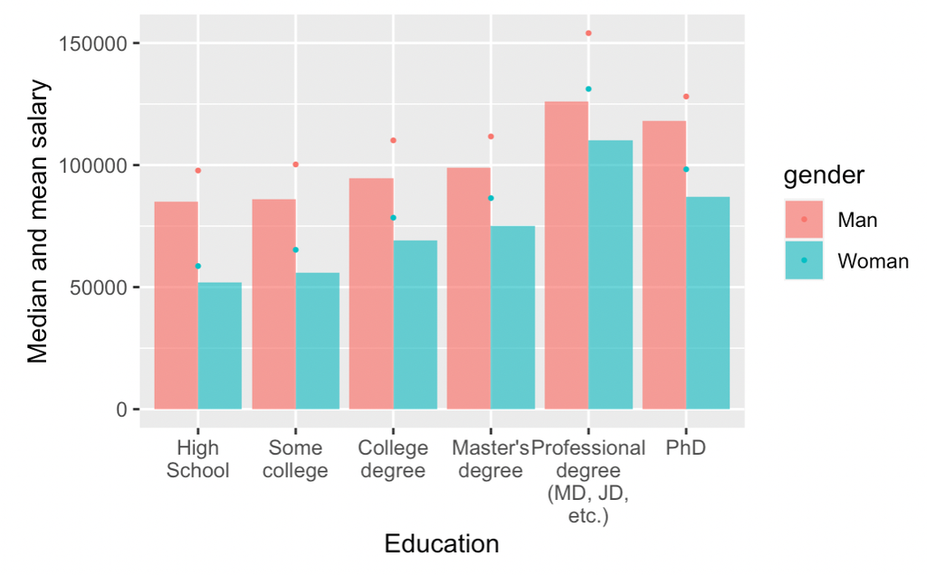

There are several fatal problems with this visualization:

- Guideline: Title and subtitle are missing from the graph, and there is no unit specified for Y-axis
- Arrangement: For the purpose of maximizing output, I put both mean salary and median salary onto the graph, but it created confusion and didn’t add anything insightful besides we know the dataset is right-skewed
- Color: Colorcoded by gender is not necessary in this visualization
- Lines: grid lines not muted

# Question 3

### Import and clean the data

```r
# Read data
stop_search <- read.csv(here::here("data/2021-09-metropolitan-stop-and-search.csv"),na.strings=c("","NA"))

# Cleaning
stop_search <- clean_names(stop_search)

stop_search <- stop_search %>%
  mutate(date = ymd(substr(date,1,10)),
         type_search = as.factor(type),
         gender = factor(gender,levels=c("Male","Female","Other")),
         ethnicity = factor(officer_defined_ethnicity,levels = c("Asian","Black","White","Other")),
         object=as.factor(object_of_search),
         outcome = as.factor(outcome),
         age_range=factor(age_range,levels = c("under 10","10-17","18-24","25-34","over 34","NA")))
```

### Weekly fluctuation for stop-and-search cases

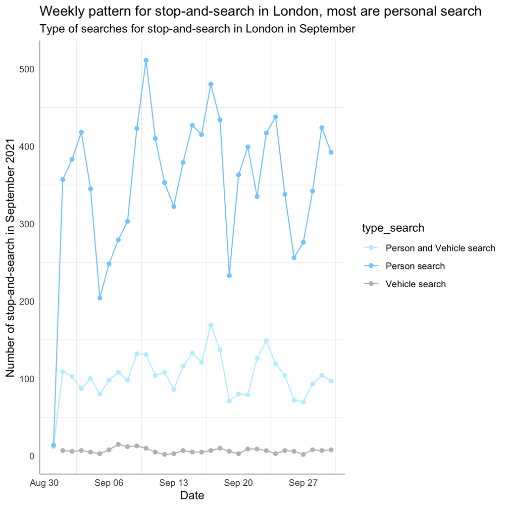

```r
ss_plot0 <- stop_search %>%
  group_by(date,type_search) %>%
  summarise(count=n())

  ggplot(ss_plot0,aes(x=date,y=count,color=type_search))+
    geom_line()+
    geom_point()+
    theme_minimal()+
  theme(legend.position="right",
        panel.grid.major = element_blank(),
        axis.line = element_line(colour = "grey"))+
  scale_color_manual(values=c("lightblue1","skyblue1","grey"))+
  labs(title = "Weekly pattern for stop-and-search in London, most are personal search",subtitle = "Type of searches for stop-and-search in London in September",x="Date",y="Number of stop-and-search in September 2021")
```

### Most stop-and-search in London target young male

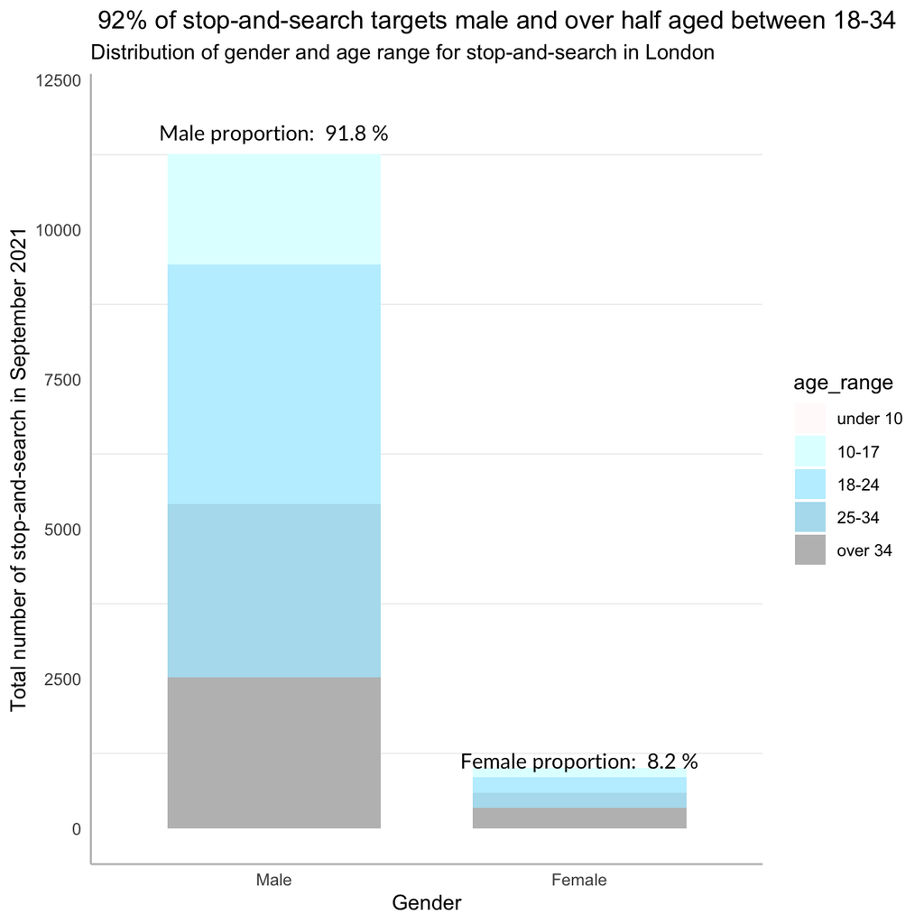

```r
ss_plot1 <- stop_search %>%
  filter((!is.na(gender))&(gender!="Other")&(!is.na(age_range))) %>%
  group_by(age_range,gender) %>%
  summarise(count=n())

gender_perc <- stop_search %>%
  filter((!is.na(gender))&(gender!="Other")&(!is.na(age_range))) %>%
  group_by(gender) %>%
  summarise(count=n()) %>%
  mutate(prop=count/sum(count))

ggplot(ss_plot1,aes(x=gender,y=count,fill = age_range))+
  geom_col(position="stack",width=0.7)+
  theme_minimal()+
    geom_text(
    data = data.frame(x = c("Male","Female"), y = c(12000,1500), label =c(paste("Male proportion: ",91.8,"%"),paste("Female proportion: ",8.2,"%"))),
    aes(x = x, y = y, label = label),
    colour="black",
    family="Lato",
    vjust = 2,
    lineheight = 1.5,
    inherit.aes = FALSE
  )+
  theme(legend.position="right",
        panel.grid.major = element_blank(),
        axis.line = element_line(colour = "grey"))+
  scale_fill_manual(values=c("snow1","lightcyan1","lightblue1","lightblue2","grey"))+
  labs(title = " 92% of stop-and-search targets male and over half aged between 18-34",subtitle = "Distribution of gender and age range for stop-and-search in London",x="Gender",y="Total number of stop-and-search in September 2021")
```

### Significant search disparity towards black people

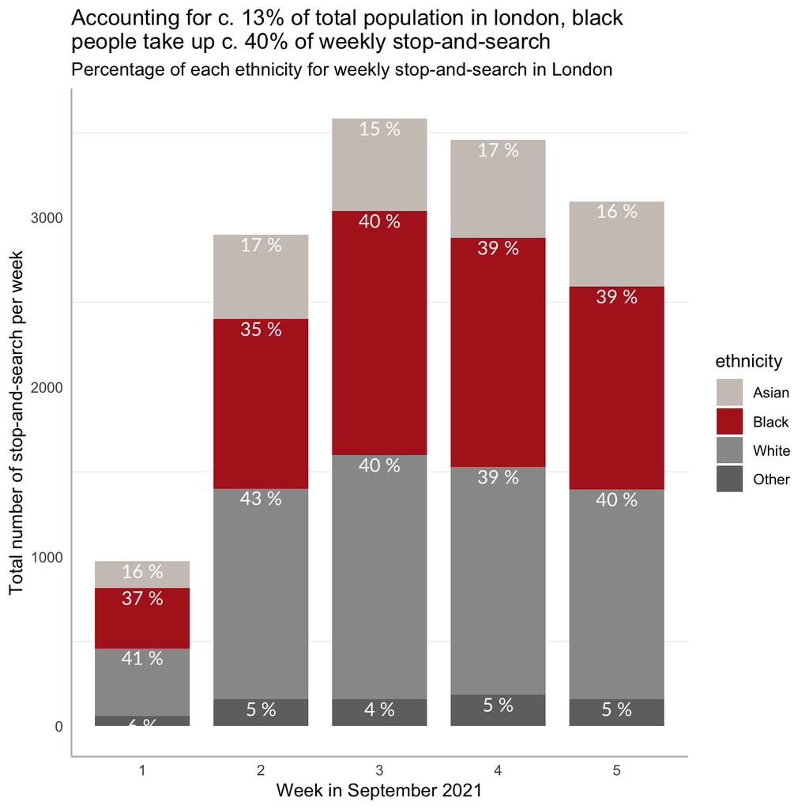

```r
ss_plot2 <- stop_search %>%
  filter(!is.na(ethnicity)) %>%
  group_by(week=week(date),ethnicity) %>%
  summarise(count = n()) %>%
  mutate(prop=count/sum(count),
         week = case_when(week == 35  ~ "1",
                          week == 36  ~ "2",
                          week == 37  ~ "3",
                          week == 38  ~ "4",
                          week == 39  ~ "5"))

plot2 <- ggplot(ss_plot2,
       aes(x=week,y=count,fill= ethnicity))+
  geom_col(width=0.8)+
    geom_text(position = position_stack(),
    aes(label = paste(round(prop*100),"%"), y=count),
    colour = "white",
    size = 4,
    vjust = 1.2,
    family="Lato"
  ) +
  theme_minimal()+
  theme(legend.position="right",
        panel.grid.major = element_blank(),
        axis.line = element_line(colour = "grey"))+
  scale_fill_manual(values=c("seashell3","firebrick","gray60","gray44"))+
  labs(title = str_wrap("Accounting for c. 13% of total population in london, black people take up c. 40% of weekly stop-and-search",width=60), subtitle = "Percentage of each ethnicity for weekly stop-and-search in London",x="Week in September 2021",y="Total number of stop-and-search per week",size=13)

plot2
```

### Controlled drugs is the most common objective with ~30% penalized rate

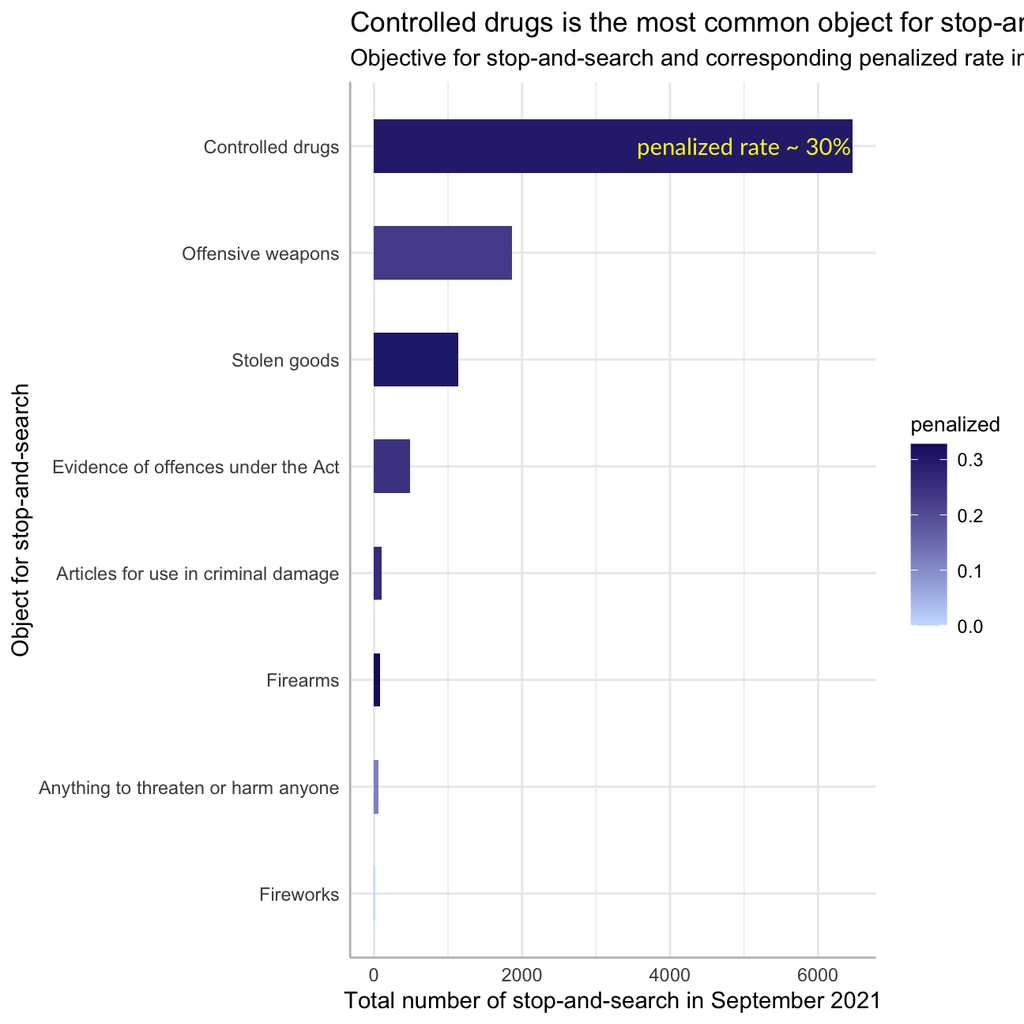

```r
ss_plot3 <- stop_search %>%
  filter(!is.na(object))%>%
  group_by(object,outcome) %>%
  summarise(count=n()) %>%
  mutate(penalized=1-count/sum(count),sum=sum(count))

test <- subset(ss_plot3,outcome=="A no further action disposal")

plot3 <- ggplot(test,aes(y=fct_reorder(object,sum),x=count,fill=penalized))+
  geom_col(position="dodge", stat="identity",width=0.5)+
  geom_text(
    data = data.frame(x = 5000, y = "Controlled drugs", label ="penalized rate ~ 30%"),
    aes(x = x, y = y, label = label),
    colour="yellow1",
    family="Lato",
    hjust = 0.5,
    lineheight = .8,
    inherit.aes = FALSE,
  )+
  scale_fill_gradient(low="lightsteelblue1", high="midnightblue")+
  theme_minimal()+
  theme(legend.position="right",
        legend.title=element_text(size=10),
        axis.line = element_line(colour = "grey"))+
  labs(title="Controlled drugs is the most common object for stop-and-search in London",subtitle = "Objective for stop-and-search and corresponding penalized rate in London",x="Total number of stop-and-search in September 2021", y="Object for stop-and-search")

plot3
```